# IE 451 Applied Data Analysis Homework 1

## 2.3 c-) Are any of the predictors associated with per capita crime rate? If so, explain the relationship.

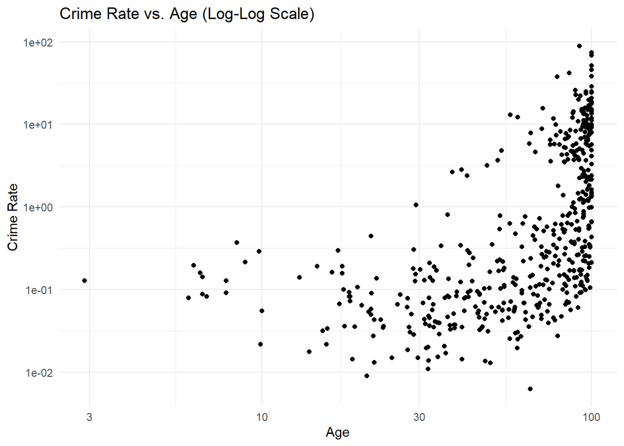

```r
ggplot(Boston, aes(x = age, y = crim)) +
  geom_point() + scale_x_log10() + scale_y_log10() +
  labs(x = "Age", y = "Crime Rate", title = "Crime Rate vs. Age (Log-Log Scale)") + theme_minimal()
```

So, graph shows that the older homes get, crime rates get higher.

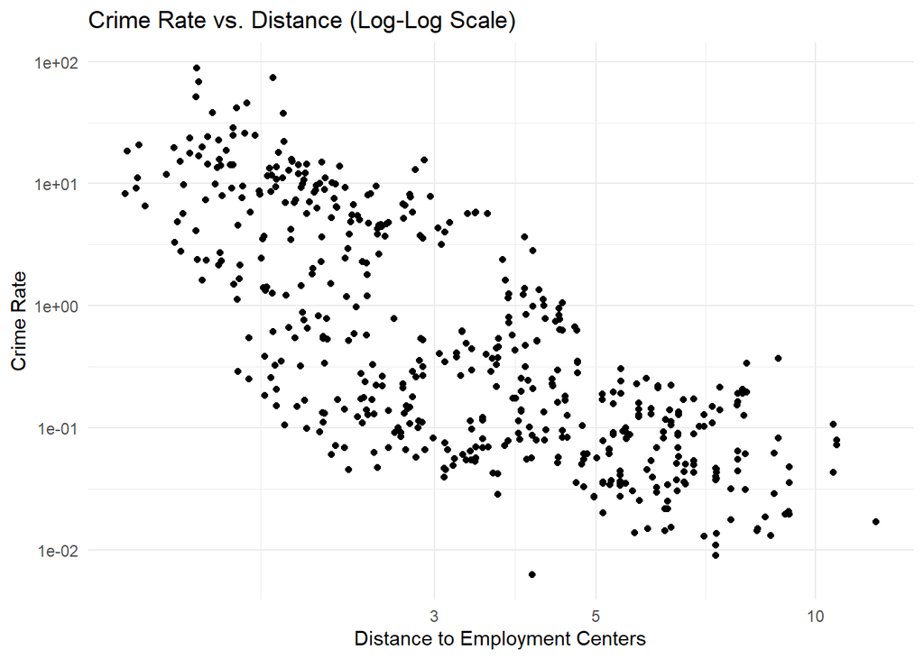

```r
ggplot(Boston, aes(x = dis, y = crim)) +
  geom_point() + scale_x_log10() + scale_y_log10() +
  labs(x = "Distance to Employment Centers", y = "Crime Rate", title = "Crime Rate vs. Distance (Log-Log Scale)") + theme_minimal()
```

Also, dis column shows weighted mean of distances to five Boston employment centers and here in graph, homes near to the employment centers has more crime rate. When distance increases, crime rates decrease.

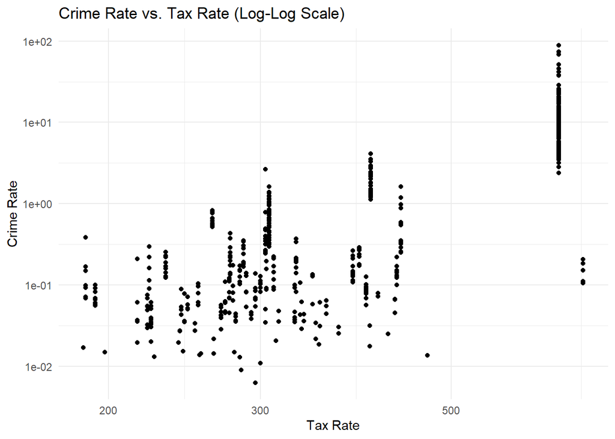

```r
ggplot(Boston, aes(x = tax, y = crim)) +
  geom_point() + scale_x_log10() +
  scale_y_log10() + labs(x = "Tax Rate", y = "Crime Rate", title = "Crime Rate vs. Tax Rate (Log-Log Scale)") + theme_minimal()
```

Here, as tax rates increases, crime rates also increase.

To find the correlations between variables:

```r
cor(Boston)
```

```
               crim          zn       indus         chas         nox
crim     1.00000000 -0.20046922  0.40658341 -0.055891582  0.42097171
zn      -0.20046922  1.00000000 -0.53382819 -0.042696719 -0.51660371
indus    0.40658341 -0.53382819  1.00000000  0.062938027  0.76365145
chas    -0.05589158 -0.04269672  0.06293803  1.000000000  0.09120281
nox      0.42097171 -0.51660371  0.76365145  0.091202807  1.00000000
rm      -0.21924670  0.31199059 -0.39167585  0.091251225 -0.30218819
age      0.35273425 -0.56953734  0.64477851  0.086517774  0.73147010
dis     -0.37967009  0.66440822 -0.70802699 -0.099175780 -0.76923011
rad      0.62550515 -0.31194783  0.59512927 -0.007368241  0.61144056
tax      0.58276431 -0.31456332  0.72076018 -0.035586518  0.66802320
ptratio  0.28994558 -0.39167855  0.38324756 -0.121515174  0.18893268
black   -0.38506394  0.17552032 -0.35697654  0.048788485 -0.38005064
lstat    0.45562148 -0.41299457  0.60379972 -0.053929298  0.59087892
medv    -0.38830461  0.36044534 -0.48372516  0.175260177 -0.42732077
                 rm         age         dis          rad         tax    ptratio
crim    -0.21924670  0.35273425 -0.37967009  0.625505145  0.58276431  0.2899456
zn       0.31199059 -0.56953734  0.66440822 -0.311947826 -0.31456332 -0.3916785
indus   -0.39167585  0.64477851 -0.70802699  0.595129275  0.72076018  0.3832476
chas     0.09125123  0.08651777 -0.09917578 -0.007368241 -0.03558652 -0.1215152
nox     -0.30218819  0.73147010 -0.76923011  0.611440563  0.66802320  0.1889327
rm       1.00000000 -0.24026493  0.20524621 -0.209846668 -0.29204783 -0.3555015
age     -0.24026493  1.00000000 -0.74788054  0.456022452  0.50645559  0.2615150
dis      0.20524621 -0.74788054  1.00000000 -0.494587930 -0.53443158 -0.2324705
rad     -0.20984667  0.45602245 -0.49458793  1.000000000  0.91022819  0.4647412
tax     -0.29204783  0.50645559 -0.53443158  0.910228189  1.00000000  0.4608530
ptratio -0.35550149  0.26151501 -0.23247054  0.464741179  0.46085304  1.0000000
black    0.12806864 -0.27353398  0.29151167 -0.444412816 -0.44180801 -0.1773833
lstat   -0.61380827  0.60233853 -0.49699583  0.488676335  0.54399341  0.3740443
medv     0.69535995 -0.37695457  0.24992873 -0.381626231 -0.46853593 -0.5077867
              black      lstat       medv
crim    -0.38506394  0.4556215 -0.3883046
zn       0.17552032 -0.4129946  0.3604453
indus   -0.35697654  0.6037997 -0.4837252
chas     0.04878848 -0.0539293  0.1752602
nox     -0.38005064  0.5908789 -0.4273208
rm       0.12806864 -0.6138083  0.6953599
age     -0.27353398  0.6023385 -0.3769546
dis      0.29151167 -0.4969958  0.2499287
rad     -0.44441282  0.4886763 -0.3816262
tax     -0.44180801  0.5439934 -0.4685359
ptratio -0.17738330  0.3740443 -0.5077867
black    1.00000000 -0.3660869  0.3334608
lstat   -0.36608690  1.0000000 -0.7376627
medv     0.33346082 -0.7376627  1.0000000
```

From these values, shortly we can say that crim, nox, indus, lstat, and rad are positively correlated with each other and generally associated with lower property values and poorer living conditions.

On the other hand rm, dis, zn, and medv tend to be positively correlated with each other, representing higher home values, better living conditions, and more suburban characteristics.

## 2.4 d-) Do any of the suburbs of Boston appear to have particularly high crime rates? Tax rates? Pupil-teacher ratios? Comment on the range of each predictor.

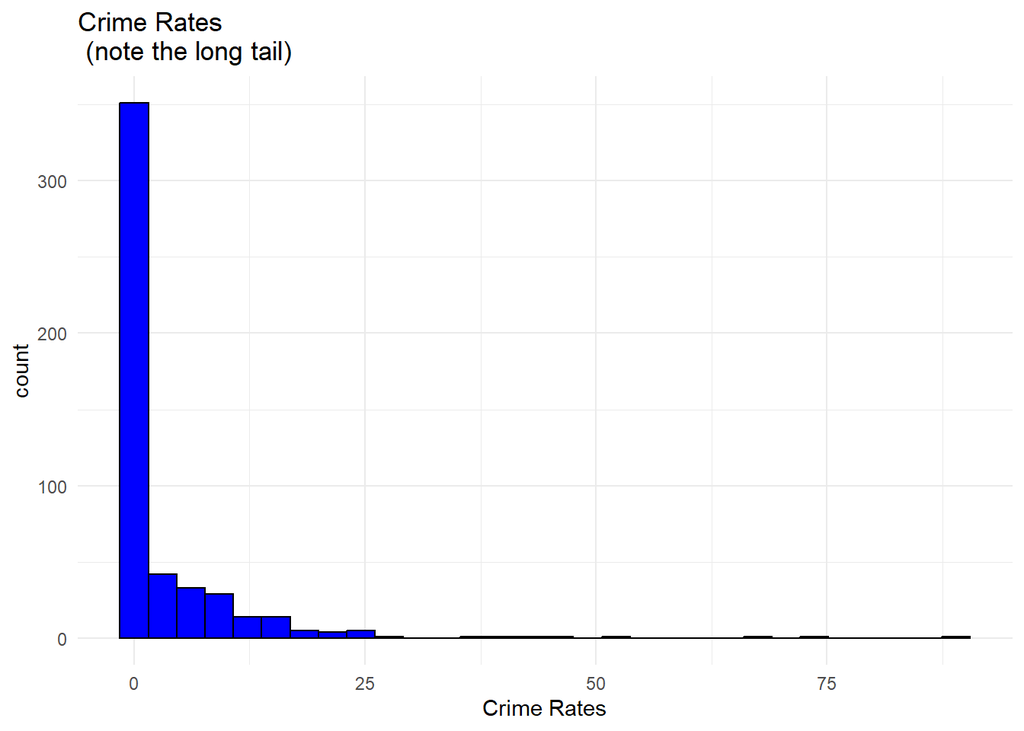

```r
ggplot(Boston, aes(x = crim)) +
  geom_histogram(bins = 30, fill = "blue", color = "black") +
  labs(x = "Crime Rates", title = "Crime Rates\n (note the long tail)") +
  theme_minimal()
```

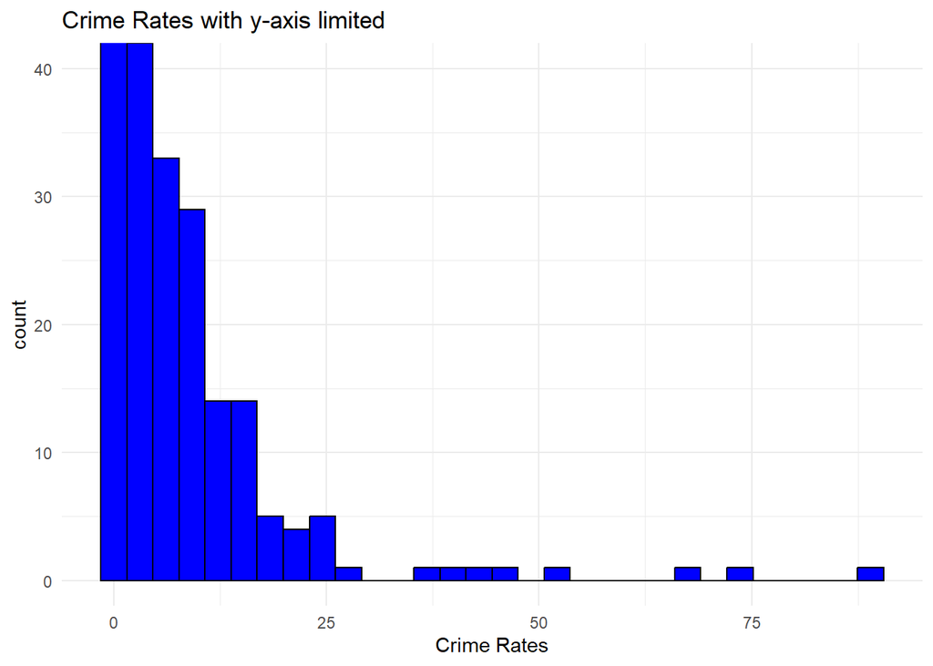

```r
ggplot(Boston, aes(x = crim)) +
  geom_histogram(bins = 30, fill = "blue", color = "black") +
  coord_cartesian(ylim = c(0, 40)) +
  labs(x = "Crime Rates", title = "Crime Rates with y-axis limited") +
  theme_minimal()
```

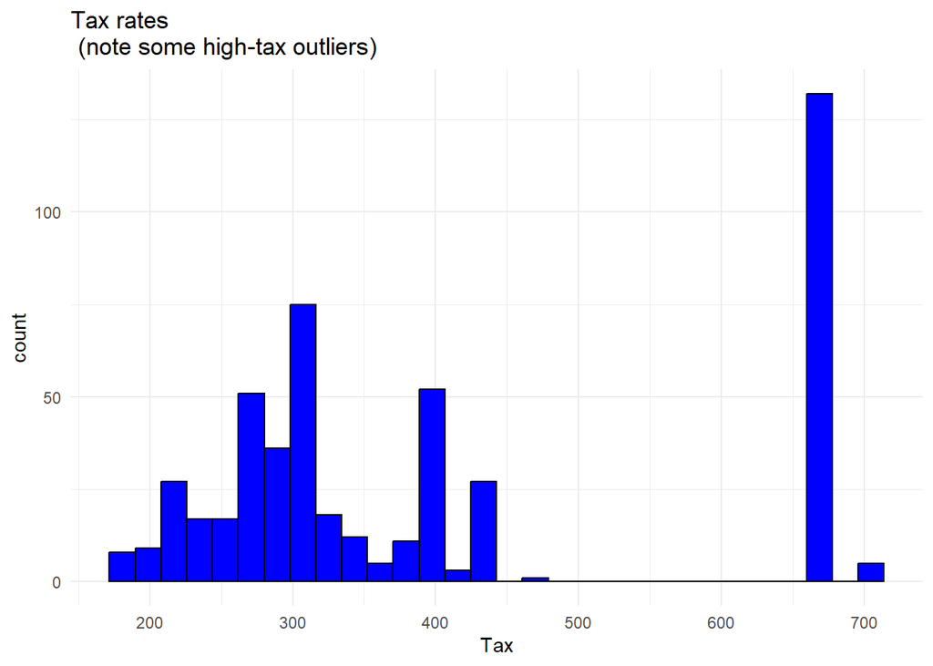

```r
ggplot(Boston, aes(x = tax)) +
  geom_histogram(bins = 30, fill = "blue", color = "black") +
  labs(x = "Tax", title = "Tax rates\n (note some high-tax outliers)") +
  theme_minimal()
```

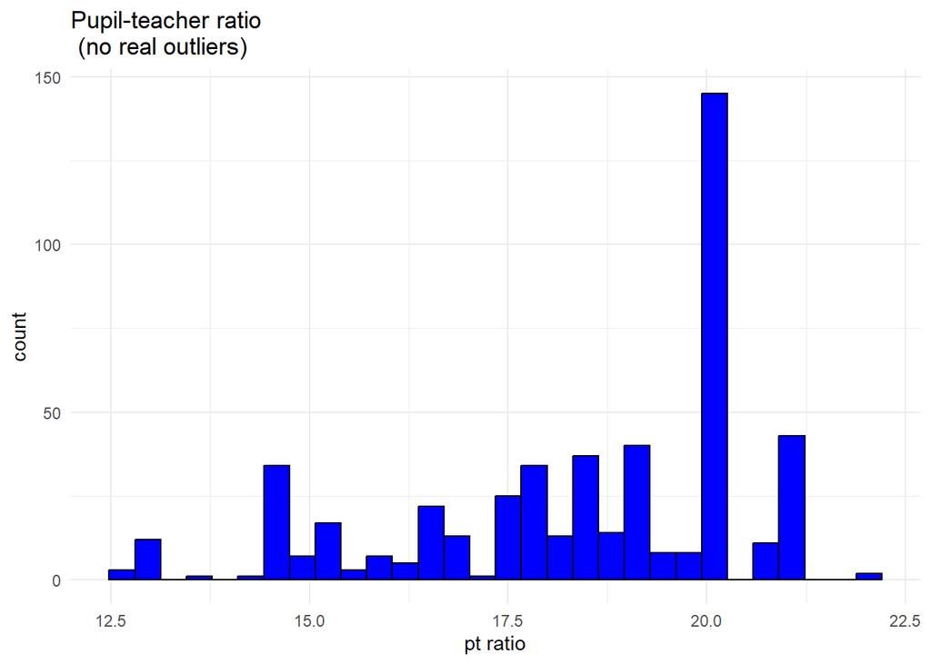

```r
ggplot(Boston, aes(x = ptratio)) +
  geom_histogram(bins = 30, fill = "blue", color = "black") +
  labs(x = "pt ratio", title = "Pupil-teacher ratio\n (no real outliers)") +
  theme_minimal()
```

My comments: Here the plots show that some suburbs in Boston have notably high crime rates, with a few extreme outliers, as indicated by the long tail in the distribution. In terms of tax rates, there are some high-tax outliers, particularly above 600, but the majority of suburbs fall between 200 and 400.

## 2.5 e-) How many of the suburbs in this data set bound the Charles river?

```r
sum(Boston$chas == 1)
```

```
[1] 35
```

## 2.6 f-)What is the median pupil-teacher ratio among the towns in this data set?

```r
median(Boston$ptratio)
```

```
[1] 19.05
```

## 2.7 g-) Which suburb of Boston has lowest median value of owneroccupied homes? What are the values of the other predictors for that suburb, and how do those values compare to the overall ranges for those predictors? Comment on your findings.

Lowest median value of owneroccupied homes is 5. And values of the other predictors for that suburb is:

```r
lowest_medv_index <- which.min(Boston$medv)

lowest_medv_suburb <- Boston[lowest_medv_index, ]

print(lowest_medv_suburb)
```

```
       crim zn indus chas   nox    rm age    dis rad tax ptratio black lstat
399 38.3518  0  18.1    0 0.693 5.453 100 1.4896  24 666    20.2 396.9 30.59
    medv
399    5
```

My comment: This area is characterized by a high crime rate and a fully industrialized zone. It also has high pollution levels, aging buildings, and a high tax rate. The pupil-teacher ratio is relatively high, and the proportion of lower-income households is reflected by a lstat value of 30.59. These factors suggest a struggling neighborhood with significant socio-economic challenges.

## 2.8 h-) In this data set, how many of the suburbs average more than seven rooms per dwelling? More than eight rooms per dwelling? Comment on the suburbs that average more than eight rooms per dwelling.

Count of suburbs more than seven rooms:

```r
sum(Boston$rm > 7)
```

```
[1] 64
```

Count of suburbs more than eight rooms:

```r
sum(Boston$rm > 8)
```

```
[1] 13
```

Now to make a comment on the suburbs that average more than eight rooms per dwelling, I will look the summary of the subset:

```r
summary(subset(Boston, rm > 8))
```

```
      crim               zn            indus             chas
 Min.   :0.02009   Min.   : 0.00   Min.   : 2.680   Min.   :0.0000
 1st Qu.:0.33147   1st Qu.: 0.00   1st Qu.: 3.970   1st Qu.:0.0000
 Median :0.52014   Median : 0.00   Median : 6.200   Median :0.0000
 Mean   :0.71879   Mean   :13.62   Mean   : 7.078   Mean   :0.1538
 3rd Qu.:0.57834   3rd Qu.:20.00   3rd Qu.: 6.200   3rd Qu.:0.0000
 Max.   :3.47428   Max.   :95.00   Max.   :19.580   Max.   :1.0000
      nox               rm             age             dis
 Min.   :0.4161   Min.   :8.034   Min.   : 8.40   Min.   :1.801
 1st Qu.:0.5040   1st Qu.:8.247   1st Qu.:70.40   1st Qu.:2.288
 Median :0.5070   Median :8.297   Median :78.30   Median :2.894
 Mean   :0.5392   Mean   :8.349   Mean   :71.54   Mean   :3.430
 3rd Qu.:0.6050   3rd Qu.:8.398   3rd Qu.:86.50   3rd Qu.:3.652
 Max.   :0.7180   Max.   :8.780   Max.   :93.90   Max.   :8.907
      rad              tax           ptratio          black
 Min.   : 2.000   Min.   :224.0   Min.   :13.00   Min.   :354.6
 1st Qu.: 5.000   1st Qu.:264.0   1st Qu.:14.70   1st Qu.:384.5
 Median : 7.000   Median :307.0   Median :17.40   Median :386.9
 Mean   : 7.462   Mean   :325.1   Mean   :16.36   Mean   :385.2
 3rd Qu.: 8.000   3rd Qu.:307.0   3rd Qu.:17.40   3rd Qu.:389.7
 Max.   :24.000   Max.   :666.0   Max.   :20.20   Max.   :396.9
     lstat           medv
 Min.   :2.47   Min.   :21.9
 1st Qu.:3.32   1st Qu.:41.7
 Median :4.14   Median :48.3
 Mean   :4.31   Mean   :44.2
 3rd Qu.:5.12   3rd Qu.:50.0
 Max.   :7.44   Max.   :50.0
```

My comment: The crime rates in these suburbs are relatively low, with a mean of 0.72 and a maximum of 3.47, suggesting safer environments. The homes are older, with an average building age of 71.54%, but the pupil-teacher ratio is favorable, with a mean of 16.36, suggesting better educational resources. Tax rates vary significantly, but the median value of homes is quite high, with a mean of 44.2 and several suburbs reaching the maximum value of 50. This subset represents well-established, higher-income neighborhoods and favorable living conditions.